# Support Vector Machines

Let’s now use a support vector machine to build a classification algorithm. Here, I am using the **e1071** package in R, which is essentially a wrapper to the LIBSVM library. It is based on the algorithm we described today (i.e., directly solving the dual problem).

## Housing data

We will start by looking the housing data.

```r
set.seed(1)
x <- read.csv("../../data/CAPA.csv", as.is=TRUE)
names(x) <- tolower(names(x))
x <- na.omit(x)
```

And construct the same training and testing sets as from the previous class:

```r
X <- x[, c(6,11:15,33:34)]
trainFlag <- (runif(nrow(x)) < 0.66)
y <- as.numeric(x$statefp == 6)
Xtrain <- X[trainFlag,]
ytrain <- y[trainFlag]
Xtest <- X[!trainFlag,]
ytest <- y[!trainFlag]
```

Fit a linear SVM; the function will try to determine whether you want to do classification or regression (we have not discussed the extension to SVM for regression). I prefer to manually specify it because it can be subtle to miss the difference:

```r
library(e1071)

out <- svm(Xtrain, ytrain, type="C-classification",
            kernel="linear")
out
```

```
##
## Call:
## svm.default(x = Xtrain, y = ytrain, type = "C-classification",
##     kernel = "linear")
##
##
## Parameters:
##    SVM-Type:  C-classification
##  SVM-Kernel:  linear
##        cost:  1
##       gamma:  0.125
##
## Number of Support Vectors:  1435
```

And then predict the results using the predict function, noting that you need to subtract one from the results to match up to the input.

```r
svmYhat <- as.numeric(predict(out, Xtest)) - 1L
mean(ytest != svmYhat)
```

```
## [1] 0.07451196
```

Specifying a linear kernel, which attempts to find a hyperplane in space to separate the classes, notice that this performs roughly as well as the tree based classification algorithms.

If we set the *kernel* parameter to the ‘radial’ kernel,

```r
out <- svm(Xtrain, ytrain, type="C-classification",
            kernel="radial")
out
```

```
##
## Call:
## svm.default(x = Xtrain, y = ytrain, type = "C-classification",
##     kernel = "radial")
##
##
## Parameters:
##    SVM-Type:  C-classification
##  SVM-Kernel:  radial
##        cost:  1
##       gamma:  0.125
##
## Number of Support Vectors:  1389
```

The support vector machine performs significantly better than the base model:

```r
svmYhat <- as.numeric(predict(out, Xtest)) - 1L
mean(ytest != svmYhat)
```

```
## [1] 0.0577399
```

We can change the cost function, and in this case observe an improvement over the default cost:

```r
out <- svm(Xtrain, ytrain, type="C-classification",
            kernel="radial", cost=5)
svmYhat <- as.numeric(predict(out, Xtest)) - 1L
mean(ytest != svmYhat)
```

```
## [1] 0.05361562
```

As before, I want to fit an additive model to the training set and then use this as a meta-predictor in the random forest and gradient boosted tree models. However, instead of directly predicting the classification response (which we could do), I will instead use the additive model to predictive the most important variable in the tree models (median number of rooms):

```r
library(mgcv)
x.gam2 <- gam(median_rooms
  ~ s(median_house_value) + s(mean_household_income)
  + s(population) + s(total_units) + s(vacant_units)
  + s(median_household_income) + s(mean_household_size_owners)
  + s(mean_household_size_renters),
    data=x, subset=trainFlag)
```

We then reconstruct the test and training matrices:

```r
x$gamPred <- predict(x.gam2, x)
X <- x[, c(6,11:15,33:35)]
y <- as.numeric(x$statefp == 6)
Xtrain <- X[trainFlag,]
ytrain <- y[trainFlag]
Xtest <- X[!trainFlag,]
ytest <- y[!trainFlag]
```

And re-run the random forest estimator:

```r
library(randomForest)
rfObj <- randomForest(Xtrain, factor(ytrain),
                      Xtest, factor(ytest),
                      do.trace=FALSE, keep.forest=TRUE,
                      ntree=500L)
rfYhat <- predict(rfObj, Xtest)
```

As well as the support vector machines:

```r
out <- svm(Xtrain, ytrain, type="C-classification",
            kernel="linear", cost=100)
svmLinearYhat <- as.numeric(predict(out, Xtest)) - 1L
out <- svm(Xtrain, ytrain, type="C-classification",
            kernel="radial")
svmRadialYhat <- as.numeric(predict(out, Xtest)) - 1L
```

And compare the results:

```r
mean(ytest != rfYhat)
```

```
## [1] 0.04756668
```

```r
mean(ytest != svmLinearYhat)
```

```
## [1] 0.04839153
```

```r
mean(ytest != svmRadialYhat)
```

```
## [1] 0.03574374
```

And so, the support vector machine performs significantly better than the random forest in this example, when we use a non-linear kernel. Note that we could further try to optimize the cost and gamma parameters to get a slightly better overall fit.

### Stacking

How different are the predicted classes from the support vector machine compared to the random forest?

```r
table(svmRadialYhat, rfYhat)
```

```
##              rfYhat
## svmRadialYhat    0    1
##             0  967   66
##             1   25 2579
```

In order to do some form of stacking, we need to compute both estimators on a probability scale. This can be done as follows:

```r
rfYhatProb <- predict(rfObj, Xtest, type="prob")[,2]
out <- svm(Xtrain, ytrain, type="C-classification",
            kernel="radial", probability=TRUE)
svmRadialYhatProb <- attributes(predict(out, Xtest, probability=TRUE))$probabilities[,1]
cor(rfYhatProb, svmRadialYhatProb)
```

```
## [1] 0.9686548
```

Notice that again, the two estimators are quite similar but not exactly the same. If we blend these together, we get a slight improvement on the SVM:

```r
newYhat <- as.numeric(rfYhatProb*0.4 + svmRadialYhatProb*0.6 > 0.5)
mean(newYhat != ytest)
```

```
## [1] 0.03464394
```

### Confusion matrix

```r
table(svmRadialYhat, ytest)
```

```
##              ytest
## svmRadialYhat    0    1
##             0  978   55
##             1   75 2529
```

It appears that we are not overly biased towards predicting points in either CA or PA. Where do these errant points occur?

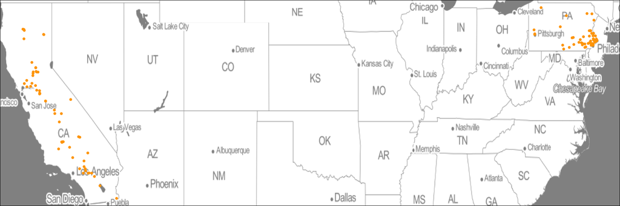

```r
these <- which(svmRadialYhat != ytest)
par(mar=c(0,0,0,0))
plot(x$longitude[!trainFlag][these], x$latitude[!trainFlag][these],
     axes=FALSE, xlab="", ylab="", col="white")
snippets::osmap(tiles.url="http://c.tile.stamen.com/toner/",alpha=0.5)
points(x$longitude[!trainFlag][these], x$latitude[!trainFlag][these],
       pch=19, cex=0.4, col="orange")
box()
```

### Hierarchical model

Switching gears for a moment, let’s consider the problem again of predicting the median house price for just the California data.

Say that we wanted to utilize the county codes in a predictive model (this is quite relevant to problem set 3); how might we do this, particularly in support vector machines, which do not natively handle categorical variables? One way is to build a hierarchical model, which first ranks the counties in some fashion and then uses that ranking as a predictor variable.

```r
set.seed(1)
x <- read.csv("../../data/CAPA.csv", as.is=TRUE)
names(x) <- tolower(names(x))
x <- na.omit(x)
ca <- x[x$statefp==6,] # just take CA data
trainFlag <- (runif(nrow(ca)) < 0.66)
```

```r
tab <- tapply(ca$median_house_value[trainFlag], ca$countyfp[trainFlag], mean)
tab
```

```
##        1        3        5        7        9       11       13       15
## 515177.3 395600.0 323742.9 256211.4 366466.7 213350.0 454139.4 207266.7
##       17       19       21       23       25       27       29       31
## 405636.0 234236.5 258660.0 303747.4 160538.1 289350.0 188555.9 252017.6
##       33       35       37       39       41       43       45       47
## 216500.0 211700.0 452806.0 237864.7 757447.6 264250.0 401793.3 203094.1
##       49       51       53       55       57       59       61       63
## 151866.7 419533.3 414477.6 510805.3 410490.9 522405.8 403832.7 217875.0
##       65       67       69       71       73       75       77       79
## 273487.7 282013.2 451857.1 264718.3 434141.0 701880.2 227706.0 527571.0
##       81       83       85       87       89       91       93       95
## 663035.7 503654.5 589356.1 591994.3 257251.9 304700.0 197236.4 333773.3
##       97       99      101      103      105      107      109      111
## 499596.6 219882.0 247230.8 194733.3 270175.0 184054.5 302162.5 496460.7
##      113      115
## 433689.3 181300.0
```

And attach this to the data set:

```r
index <- match(ca$countyfp, names(tab))
ca$countyMHP <- tab[index]
X <- ca[, c(6,11:15,33:35)]
y <- log(ca$median_house_value)
Xtrain <- X[trainFlag,]
ytrain <- y[trainFlag]
Xtest <- X[!trainFlag,]
ytest <- y[!trainFlag]
```

Now, we can use this a random forest with this meta-predictor variable

```r
rfObj <- randomForest(Xtrain, ytrain, Xtest, ytest,
                      do.trace=FALSE, keep.forest=TRUE,
                      ntree=500)
rfObj
```

```
##
## Call:
##  randomForest(x = Xtrain, y = ytrain, xtest = Xtest, ytest = ytest,      ntree = 500, do.trace = FALSE, keep.forest = TRUE)
##                Type of random forest: regression
##                      Number of trees: 500
## No. of variables tried at each split: 3
##
##           Mean of squared residuals: 0.07314528
##                     % Var explained: 73.11
##                        Test set MSE: 0.08
##                     % Var explained: 72.72
```

```r
importance(rfObj)
```

```
##                             IncNodePurity
## population                       43.21423
## total_units                      38.21183
## vacant_units                     43.61819
## median_rooms                     87.65921
## mean_household_size_owners       59.91909
## mean_household_size_renters      83.30742
## median_household_income         191.94969
## mean_household_income           354.59927
## countyMHP                       391.37913
```